# Empirical Exercise 2, Stock and Watson Chapter 8

Econ 440 - Introduction to Econometrics

Patrick Toche, ptoche@fullerton.edu

17 April 2022

## Empirical Exercise: Earnings

The data file **CPS2015** contains data for full-time, full-year workers, ages 25–34, with a high school diploma or B.A./B.S. as their highest degree. A detailed description is given in **CPS2015_Description**. In this exercise, you will investigate the relationship between a worker's age and earnings

### Dataset:

```r
library(readxl)
df <- read_xlsx("CPS2015.xlsx", trim_ws=TRUE)
head(df)
```

```
## # A tibble: 6 × 5
##    year   ahe bachelor female   age
##   <dbl> <dbl>    <dbl>  <dbl> <dbl>
## 1  2015 11.8         0      0    26
## 2  2015  9.62        0      1    33
## 3  2015 12.0         0      0    31
## 4  2015 18.4         0      0    32
## 5  2015 41.8         0      0    28
## 6  2015 19.2         0      1    31
```

## (a)

Run a regression of average hourly earnings ($ahe$) on age ($age$), sex ($female$), and education ($bachelor$). If $age$ increases from 25 to 26, how are earnings expected to change? If $age$ increases from 33 to 34, how are earnings expected to change?

```r
m1 <- lm(ahe ~ age + female + bachelor, data=df)
summary(m1)
```

```
##
## Call:
## lm(formula = ahe ~ age + female + bachelor, data = df)
##
## Residuals:
##    Min     1Q Median     3Q    Max
## -27.91  -6.65  -1.87   4.25  83.91
##
## Coefficients:
##             Estimate Std. Error t value Pr(>|t|)
## (Intercept)   2.0448     1.3547    1.51     0.13
## age           0.5313     0.0451   11.79   <2e-16 ***
## female       -4.1435     0.2659  -15.58   <2e-16 ***
## bachelor      9.8456     0.2624   37.52   <2e-16 ***
## ---
## Signif. codes:  0 '***' 0.001 '**' 0.01 '*' 0.05 '.' 0.1 ' ' 1
##
## Residual standard error: 10.9 on 7094 degrees of freedom
## Multiple R-squared:  0.19,   Adjusted R-squared:  0.189
## F-statistic:  553 on 3 and 7094 DF,  p-value: <2e-16
```

If $age$ increases by 1 year, $ahe$ is expected to increase by $\$0.5313$, that is about $53$ cents per hour. Thus, the answer is the same for an increase from 25 to 26 and from 33 to 34. We can make a prediction for the values, rather than the increase. For convenience, we use R's built-in function.

```r
newdata <- data.frame(age=c(25,26), female=rep(0,2), bachelor=rep(0,2))
predict(m1, newdata)
```

```
##      1      2
## 15.327 15.858
```

As $age$ increases from 25 to 26, earnings increase from $15.327$ to $15.858$

```r
newdata <- data.frame(age=c(33,34), female=rep(0,2), bachelor=rep(0,2))
predict(m1, newdata)
```

```
##      1      2
## 19.577 20.108
```

As $age$ increases from 33 to 34, earnings increase from $19.577$ to $20.108$

As this is a repeat question, let's build a convenience function:

```r
lm_predict <- function(model, data){
  n <- length(data)
  newdata <- data.frame(age=data,
                        female=rep(0,n),
                        bachelor=rep(0,n),
                        predicted=rep(1,n))
  newdata$ahe <- predict(model, newdata)
  newdata
}
lm_predict(m1, data=c(33,34))
```

```
##   age female bachelor predicted    ahe
## 1  33      0        0         1 19.577
## 2  34      0        0         1 20.108
```

## (b)

Run a regression of the logarithm of average hourly earnings, $ln(ahe)$, on $age$, $female$, and $bachelor$. If $age$ increases from 25 to 26, how are earnings expected to change? If $age$ increases from 33 to 34, how are earnings expected to change?

```r
m2 <- lm(log(ahe) ~ age + female + bachelor, data=df)
summary(m2)
```

```
##
## Call:
## lm(formula = log(ahe) ~ age + female + bachelor, data = df)
##
## Residuals:
##     Min      1Q  Median      3Q     Max
## -2.5980 -0.2879  0.0078  0.3008  2.0631
##
## Coefficients:
##             Estimate Std. Error t value Pr(>|t|)
## (Intercept)  2.02736    0.05924    34.2   <2e-16 ***
## age          0.02419    0.00197    12.3   <2e-16 ***
## female      -0.17762    0.01163   -15.3   <2e-16 ***
## bachelor     0.46150    0.01148    40.2   <2e-16 ***
## ---
## Signif. codes:  0 '***' 0.001 '**' 0.01 '*' 0.05 '.' 0.1 ' ' 1
##
## Residual standard error: 0.477 on 7094 degrees of freedom
## Multiple R-squared:  0.208,  Adjusted R-squared:  0.208
## F-statistic:  622 on 3 and 7094 DF,  p-value: <2e-16
```

Because the regression involves non-linear transformations of the original variables, interpreting the coefficients requires great care.

```r
exp(m2$coefficients[["age"]])-1
```

```
## [1] 0.024486
```

```r
m2$coefficients[["age"]] * (log(34)-log(33))
```

```
## [1] 0.00072218
```

Specifically, the predicted values of $ahe$ are:

```r
lm_predict(m2, data=c(25,26,33,34))
```

```
##   age female bachelor predicted    ahe
## 1  25      0        0         1 2.6321
## 2  26      0        0         1 2.6563
## 3  33      0        0         1 2.8257
## 4  34      0        0         1 2.8499
```

## (c)

Run a regression of the logarithm of average hourly earnings, $ln(ahe)$, on $ln(age)$, $female$, and $bachelor$. If $age$ increases from 25 to 26, how are earnings expected to change? If $age$ increases from 33 to 34, how are earnings expected to change?

```r
m3 <- lm(log(ahe) ~ log(age) + female + bachelor, data=df)
summary(m3)
```

```
##
## Call:
## lm(formula = log(ahe) ~ log(age) + female + bachelor, data = df)
##
## Residuals:
##    Min     1Q Median     3Q    Max
## -2.594 -0.287  0.010  0.302  2.062
##
## Coefficients:
##             Estimate Std. Error t value Pr(>|t|)
## (Intercept)   0.3233     0.1961    1.65    0.099 .
## log(age)      0.7154     0.0578   12.37   <2e-16 ***
## female       -0.1775     0.0116  -15.27   <2e-16 ***
## bachelor      0.4615     0.0115   40.22   <2e-16 ***
## ---
## Signif. codes:  0 '***' 0.001 '**' 0.01 '*' 0.05 '.' 0.1 ' ' 1
##
## Residual standard error: 0.477 on 7094 degrees of freedom
## Multiple R-squared:  0.209,  Adjusted R-squared:  0.208
## F-statistic:  623 on 3 and 7094 DF,  p-value: <2e-16
```

Both $ahe$ and $age$ appear in log form. As a result, it is no longer true that an increase in $age$ by 1 year increases $ahe$ uniformly: instead the effect on $ahe$ depends on $age$ and must be computed separately for each case.

If $age$ increases by 1 year, from 25 to 26, $ahe$ is expected to increase by about $2.8\%$:
$$\Delta\widehat{ln(ahe)} = 0.7154 \cdot (\ln(26)-\ln(25))
\approx 0.028$$
This calculation follows from:

```r
m3$coefficients[["log(age)"]] * (log(26)-log(25))
```

```
## [1] 0.028058
```

If $age$ increases by 1 year from 33 to 34, the increase in $ahe$ is smaller, at about $2.1\%$.
$$\Delta\widehat{ln(ahe)} = 0.7154 \cdot (\ln(34)-\ln(33))
\approx 0.021$$

```r
m3$coefficients[["log(age)"]] * (log(34)-log(33))
```

```
## [1] 0.021356
```

Specifically, the predicted values of $ahe$ are:

```r
lm_predict(m3, data=c(25,26,33,34))
```

```
##   age female bachelor predicted    ahe
## 1  25      0        0         1 2.6260
## 2  26      0        0         1 2.6540
## 3  33      0        0         1 2.8246
## 4  34      0        0         1 2.8459
```

## (d)

Run a regression of the logarithm of average hourly earnings, $ln(ahe)$, on $age$, $age2$, $female$, and $bachelor$. If $age$ increases from 25 to 26, how are earnings expected to change? If $age$ increases from 33 to 34, how are earnings expected to change?

```r
m4 <- lm(log(ahe) ~ age + I(age^2) + female + bachelor, data=df)
summary(m4)
```

```
##
## Call:
## lm(formula = log(ahe) ~ age + I(age^2) + female + bachelor, data = df)
##
## Residuals:
##     Min      1Q  Median      3Q     Max
## -2.5764 -0.2868  0.0126  0.3041  2.0596
##
## Coefficients:
##              Estimate Std. Error t value Pr(>|t|)
## (Intercept)  0.418745   0.672088    0.62   0.5333
## age          0.134115   0.045791    2.93   0.0034 **
## I(age^2)    -0.001860   0.000774   -2.40   0.0163 *
## female      -0.177364   0.011626  -15.26   <2e-16 ***
## bachelor     0.461629   0.011473   40.24   <2e-16 ***
## ---
## Signif. codes:  0 '***' 0.001 '**' 0.01 '*' 0.05 '.' 0.1 ' ' 1
##
## Residual standard error: 0.477 on 7093 degrees of freedom
## Multiple R-squared:  0.209,  Adjusted R-squared:  0.209
## F-statistic:  469 on 4 and 7093 DF,  p-value: <2e-16
```

## (e)

Do you prefer the regression in (c) to the regression in (b)? Explain.

The difference between the regressions in (b) and (c) is that $age$ is replaced by $log(age)$. The statistical analysis does not point to any major differences. The individual coefficients all have near-zero p-values. The regression's standard error is about the same. The regression's adjusted R-squared is about the same. The regression's p-value is near zero in both cases. The main reason for preferring regression (c) is that the coefficient on $log(age)$ can be interpreted as an elasticity.

## (f)

Do you prefer the regression in (d) to the regression in (b)? Explain.

The difference between regression (b) and regression (d) is that the linear regressor $age$ is replaced by a quadratic polynomial in $age$ and $age^2$. The regression's standard error, adjusted R-squared, and p-value do not give arguments in favor of one or the other. However, since the individual coefficient on $age^2$ is significant at the $0.05$ level, suggesting the presence of some non-linearity, we prefer regression (d).

## (g)

Do you prefer the regression in (d) to the regression in (c)? Explain.

The difference between regression (c) and regression (d) is that $log(age)$ is replaced by a quadratic polynomial in $age$ and $age^2$. The regression's standard error, adjusted R-squared, and p-value do not give arguments in favor of one or the other. We prefer regression (c) because it is parsimonious and the coefficient may be interpreted as an elasticity.

## Remark

Differences in the R-squared across the models are non-existent or tiny and cannot be used to discriminate across models, despite what some model answers out there in the internets are saying.

## (h)

Plot the regression relation between $age$ and $ln(ahe)$ from (b), (c), and (d) for males with a high school diploma. Describe the similarities and differences between the estimated regression functions. Would your answer change if you plotted the regression function for females with college degrees?

## Create labels

Create labels to replace “0” and “1” with “Male”/“Female” and “High School”/“Bachelor”

```r
female.labs <- c("0" = "Male", "1" = "Female")
bachelor.labs <- c("0" = "High School", "1" = "Bachelor")
```

## Augment the datasets

Augment the datasets with the regression results (from broom package):

```r
dm1 <- augment(m1, data=df)
dm2 <- augment(m2, data=df)
dm3 <- augment(m3, data=df)
dm4 <- augment(m4, data=df)
```

## Plot of $log(ahe|female=0,bachelor=0)$ against $age$

### for regression (b)

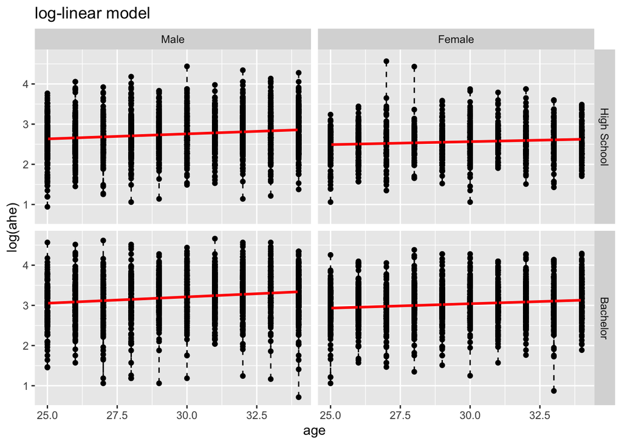

```r
ggplot(data=dm2, aes(x=age, y=log(ahe))) +
    geom_point() +
    facet_grid(bachelor~female,
               labeller=labeller(bachelor=bachelor.labs, female=female.labs)) +
    geom_smooth(method="lm", color="red",se=FALSE) +
    geom_segment(aes(xend=age, yend = .fitted), linetype="dashed") +
    ggtitle("log-linear model")
```

### for regression (c)

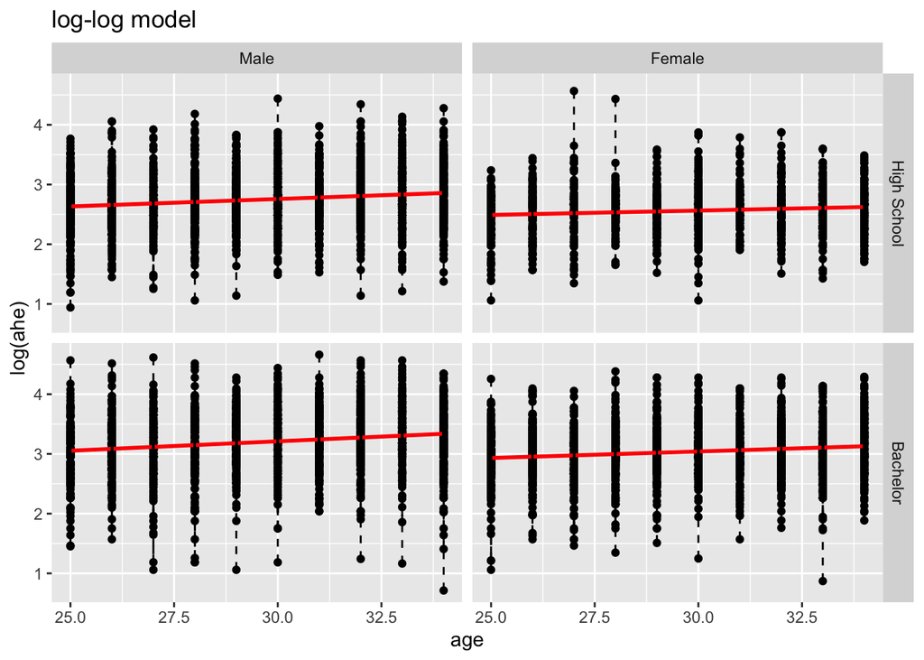

```r
ggplot(data=dm3, aes(x=age, y=log(ahe))) +
    geom_point() +
    facet_grid(bachelor~female,
               labeller=labeller(bachelor=bachelor.labs, female=female.labs)) +
    geom_smooth(method="lm", color="red",se=FALSE) +
    geom_segment(aes(xend=age, yend = .fitted), linetype="dashed") +
    ggtitle("log-log model")
```

### for regression (d)

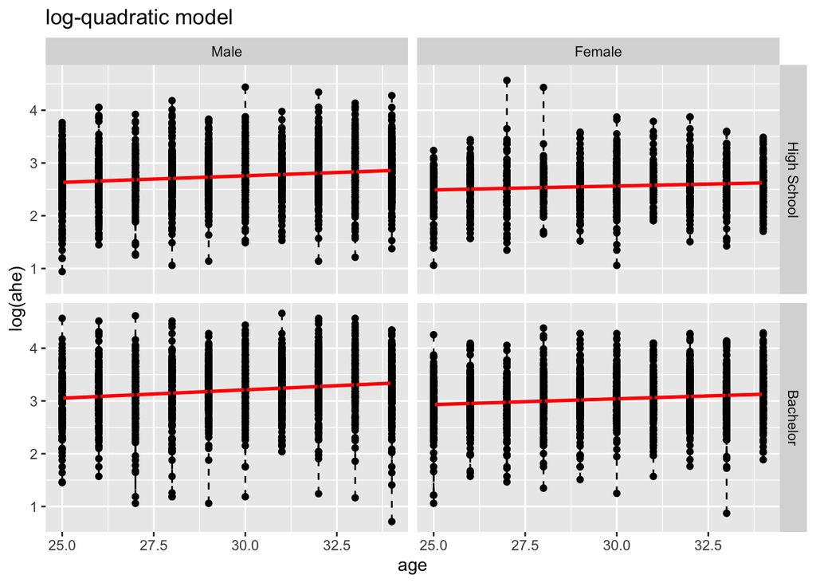

```r
ggplot(data=dm4, aes(x=age, y=log(ahe))) +
    geom_point() +
    facet_grid(bachelor~female,
               labeller=labeller(bachelor=bachelor.labs, female=female.labs)) +
    geom_smooth(method="lm", color="red",se=FALSE) +
    geom_segment(aes(xend=age, yend = .fitted), linetype="dashed") +
    ggtitle("log-quadratic model")
```

## Discussion: Model (c) vs. Model (d)

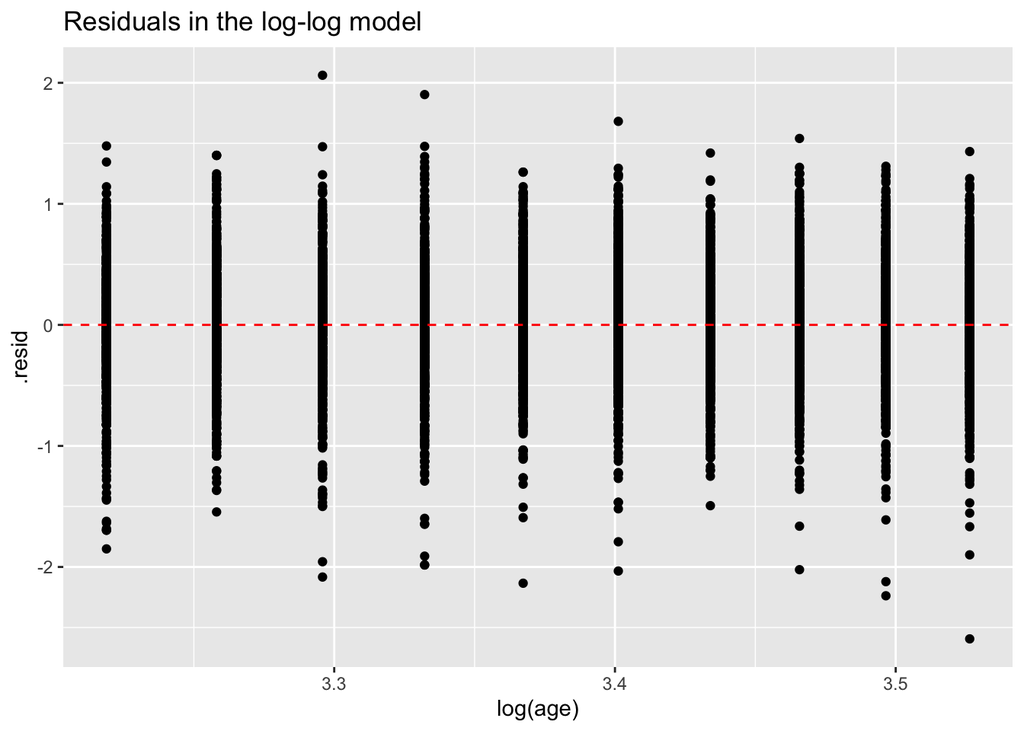

```r
ggplot(dm3, aes(log(age), .resid)) +
  geom_point() +
  geom_hline(yintercept=0, color="red", linetype='dashed') +
  ggtitle("Residuals in the log-log model")
```

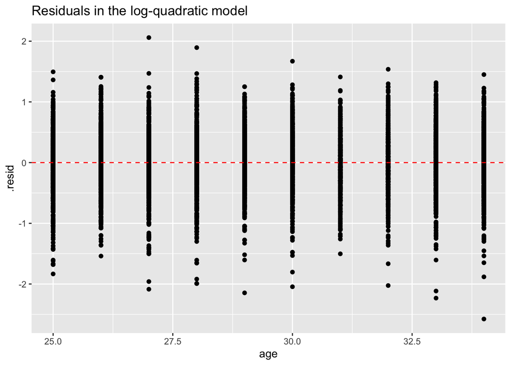

```r
ggplot(dm4, aes(age, .resid)) +
  geom_point() +
  geom_hline(yintercept=0, color="red", linetype='dashed') +
  ggtitle("Residuals in the log-quadratic model")
```

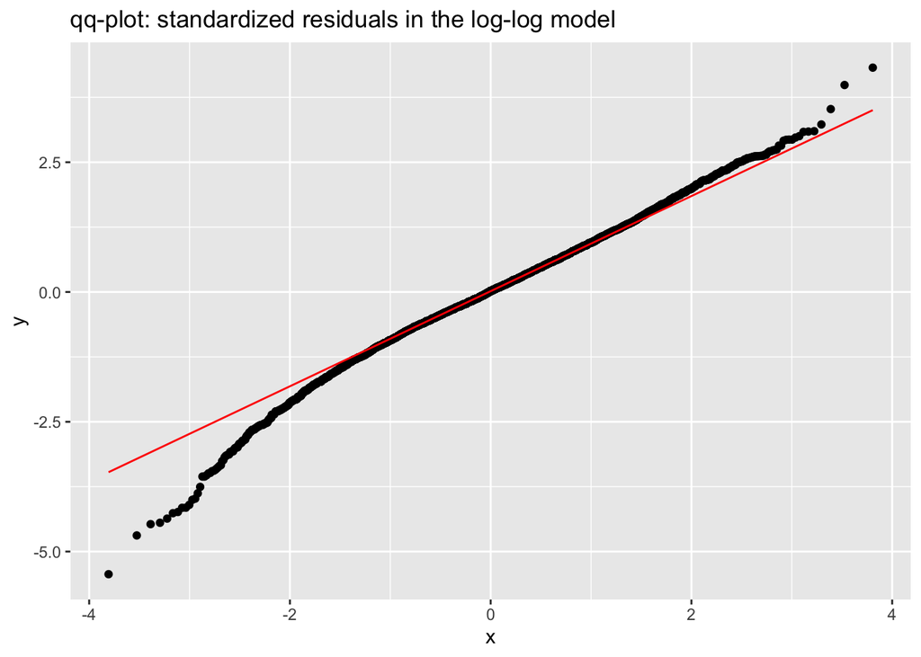

```r
ggplot(dm3, aes(sample=.std.resid)) +
  geom_qq() +
  geom_qq_line(color="red") +
  ggtitle("qq-plot: standardized residuals in the log-log model")
```

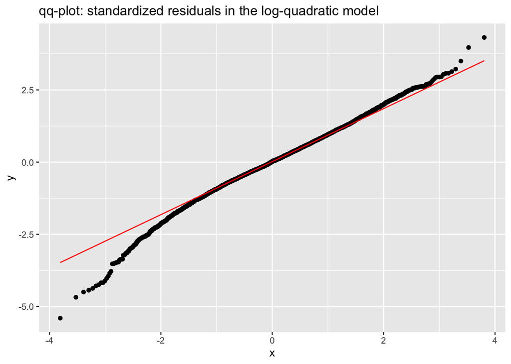

```r
ggplot(dm4, aes(sample=.std.resid)) +
  geom_qq() +
  geom_qq_line(color="red") +
  ggtitle("qq-plot: standardized residuals in the log-quadratic model")
```

## Models compared

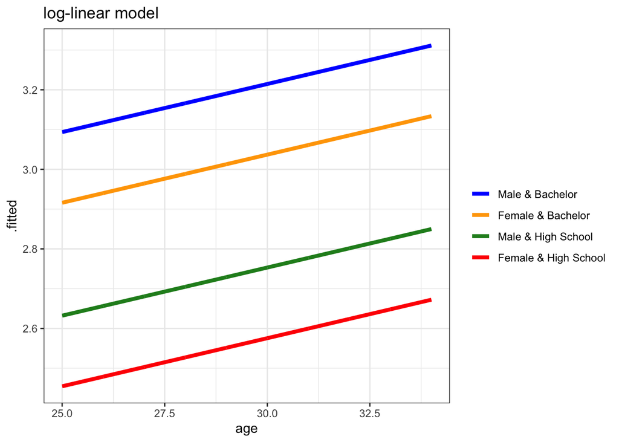

```r
print(p2)
```

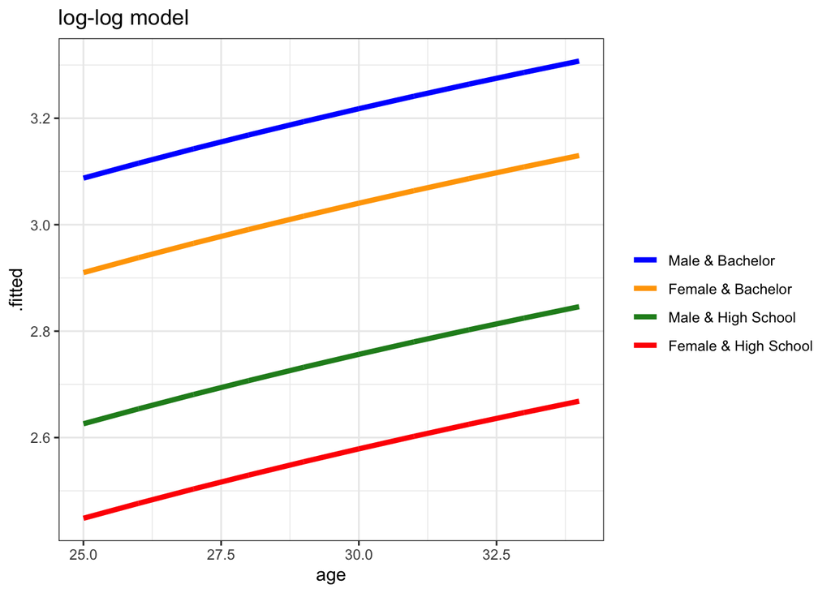

```r
print(p3)
```

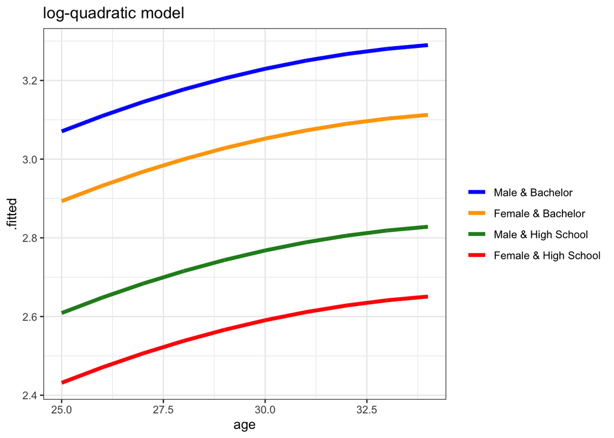

```r
print(p4)
```

## (i)

Run a regression of $ln(ahe)$ on $age$, $age2$, $female$, $bachelor$, and the interaction term $female * bachelor$.

```r
df$age2 <- (df$age)^2
df$femalebachelor <- df$female * df$bachelor
m5 <- lm(log(ahe) ~ age + age2 + female + bachelor + femalebachelor, data=df)
dm5 <- augment(m5, data=df)
summary(m5)
```

```
##
## Call:
## lm(formula = log(ahe) ~ age + age2 + female + bachelor + femalebachelor,
##     data = df)
##
## Residuals:
##     Min      1Q  Median      3Q     Max
## -2.5715 -0.2859  0.0128  0.3042  2.0683
##
## Coefficients:
##                 Estimate Std. Error t value Pr(>|t|)
## (Intercept)     0.411904   0.672122    0.61   0.5400
## age             0.134815   0.045796    2.94   0.0033 **
## age2           -0.001871   0.000774   -2.42   0.0157 *
## female         -0.190324   0.017373  -10.96   <2e-16 ***
## bachelor        0.452114   0.014882   30.38   <2e-16 ***
## femalebachelor  0.023474   0.023384    1.00   0.3155
## ---
## Signif. codes:  0 '***' 0.001 '**' 0.01 '*' 0.05 '.' 0.1 ' ' 1
##
## Residual standard error: 0.477 on 7092 degrees of freedom
## Multiple R-squared:  0.209,  Adjusted R-squared:  0.209
## F-statistic:  375 on 5 and 7092 DF,  p-value: <2e-16
```

### What does the coefficient on the interaction term measure?

The coefficient shows the extra effect on earnings for females with a bachelor degree that is not captured by the average female and not captured by the average bachelor.

### Alexis and Jane: 30-year old females

Alexis is a 30-year-old female with a bachelor's degree. What does the regression predict for her value of $ln(ahe)$? Jane is a 30-year-old female with a high school diploma. What does the regression predict for her value of $ln(ahe)$? What is the predicted difference between Alexis's and Jane's earnings?

```r
alexis <- data.frame(age=30, age2=30^2, bachelor=1, female=1, femalebachelor=1)
log.ahe.alexis = predict(m5, newdata=alexis)
ahe.alexis = exp(log.ahe.alexis)
jane <- data.frame(age=30, age2=30^2, bachelor=0, female=1, femalebachelor=0)
log.ahe.jane = predict(m5, newdata=jane)
ahe.jane = exp(log.ahe.jane)
```

```r
ahe.alexis - ahe.jane
```

```
##      1
## 8.0537
```

### Bob and Jim: 30-year old males

Bob is a 30-year-old male with a bachelor's degree. What does the regression predict for his value of $ln(ahe)$? Jim is a 30-year-old male with a high school diploma. What does the regression predict for his value of $ln(ahe)$? What is the predicted difference between Bob's and Jim's earnings?

```r
bob <- data.frame(age=30, age2=30^2, bachelor=1, female=0, femalebachelor=1)
log.ahe.bob = predict(m5, newdata=bob)
ahe.bob = exp(log.ahe.bob)
jim <- data.frame(age=30, age2=30^2, bachelor=0, female=0, femalebachelor=0)
log.ahe.jim = predict(m5, newdata=jim)
ahe.jim = exp(log.ahe.jim)
```

```r
ahe.bob - ahe.jim
```

```
##     1
## 9.742
```

### Difference-in-Difference

```r
(ahe.bob - ahe.jim) - (ahe.alexis - ahe.jane)
```

```
##      1
## 1.6884
```

## (j)

Is the effect of Age on earnings different for men than for women? Specify and estimate a regression that you can use to answer this question.

A parsimonious model is the following:

```r
m6 <- lm(log(ahe) ~ log(age) + bachelor + log(age)*female + bachelor*female, data=df)
summary(m6)
```

```
##
## Call:
## lm(formula = log(ahe) ~ log(age) + bachelor + log(age) * female +
##     bachelor * female, data = df)
##
## Residuals:
##     Min      1Q  Median      3Q     Max
## -2.6044 -0.2856  0.0035  0.3030  2.0577
##
## Coefficients:
##                 Estimate Std. Error t value Pr(>|t|)
## (Intercept)      -0.0512     0.2580   -0.20    0.843
## log(age)          0.8273     0.0762   10.86   <2e-16 ***
## bachelor          0.4515     0.0149   30.34   <2e-16 ***
## female            0.6888     0.3967    1.74    0.083 .
## log(age):female  -0.2597     0.1171   -2.22    0.027 *
## bachelor:female   0.0225     0.0234    0.96    0.336
## ---
## Signif. codes:  0 '***' 0.001 '**' 0.01 '*' 0.05 '.' 0.1 ' ' 1
##
## Residual standard error: 0.477 on 7092 degrees of freedom
## Multiple R-squared:  0.209,  Adjusted R-squared:  0.209
## F-statistic:  375 on 5 and 7092 DF,  p-value: <2e-16
```

```r
library(car)
H0 <- c("female=0", "log(age):female", "bachelor:female=0")
tidy(linearHypothesis(m6, H0))
```

```
## # A tibble: 2 × 6
##   res.df   rss    df sumsq statistic   p.value
##    <dbl> <dbl> <dbl> <dbl>     <dbl>     <dbl>
## 1   7095 1670.    NA  NA        NA   NA
## 2   7092 1615.     3  54.5      79.7  1.03e-50
```

To test whether the effect of $age$ on $ahe$ is different for men and women, we test the hypothesis that all coefficients involving $female$ are jointly zero. This hypothesis can be firmly rejected since the joint p-value is essentially zero.

## (k)

Is the effect of Age on earnings different for high school graduates than for college graduates? Specify and estimate a regression that you can use to answer this question.

```r
m7 <- lm(log(ahe) ~ log(age) + female + log(age)*bachelor + female*bachelor, data=df)
summary(m7)
```

```
##
## Call:
## lm(formula = log(ahe) ~ log(age) + female + log(age) * bachelor +
##     female * bachelor, data = df)
##
## Residuals:
##     Min      1Q  Median      3Q     Max
## -2.5990 -0.2856  0.0087  0.3024  2.0640
##
## Coefficients:
##                   Estimate Std. Error t value Pr(>|t|)
## (Intercept)         0.5865     0.2850    2.06     0.04 *
## log(age)            0.6389     0.0842    7.59  3.6e-14 ***
## female             -0.1901     0.0174  -10.94  < 2e-16 ***
## bachelor           -0.0518     0.3929   -0.13     0.90
## log(age):bachelor   0.1488     0.1159    1.28     0.20
## female:bachelor     0.0237     0.0234    1.01     0.31
## ---
## Signif. codes:  0 '***' 0.001 '**' 0.01 '*' 0.05 '.' 0.1 ' ' 1
##
## Residual standard error: 0.477 on 7092 degrees of freedom
## Multiple R-squared:  0.209,  Adjusted R-squared:  0.208
## F-statistic:  375 on 5 and 7092 DF,  p-value: <2e-16
```

```r
library(car)
H0 <- c("bachelor=0", "log(age):bachelor", "female:bachelor=0")
tidy(linearHypothesis(m7, H0))
```

```
## # A tibble: 2 × 6
##   res.df   rss    df sumsq statistic    p.value
##    <dbl> <dbl> <dbl> <dbl>     <dbl>      <dbl>
## 1   7095 1985.    NA   NA        NA  NA
## 2   7092 1616.     3  369.      540.  3.60e-316
```

## (l)

After running all these regressions (and any others that you want to run), summarize the effect of age on earnings for young workers.

The following models fit about $21\%$ of the deviation of average hourly earnings from the sample mean. It's not immediately obvious that one should be preferred over the other.

### Log-quadratic model:

```r
m8 <- lm(log(ahe) ~ poly(age,2,raw=TRUE) + bachelor + female, data=df)
summary(m8)
```

```
##
## Call:
## lm(formula = log(ahe) ~ poly(age, 2, raw = TRUE) + bachelor +
##     female, data = df)
##
## Residuals:
##     Min      1Q  Median      3Q     Max
## -2.5764 -0.2868  0.0126  0.3041  2.0596
##
## Coefficients:
##                            Estimate Std. Error t value Pr(>|t|)
## (Intercept)                0.418745   0.672088    0.62   0.5333
## poly(age, 2, raw = TRUE)1  0.134115   0.045791    2.93   0.0034 **
## poly(age, 2, raw = TRUE)2 -0.001860   0.000774   -2.40   0.0163 *
## bachelor                   0.461629   0.011473   40.24   <2e-16 ***
## female                    -0.177364   0.011626  -15.26   <2e-16 ***
## ---
## Signif. codes:  0 '***' 0.001 '**' 0.01 '*' 0.05 '.' 0.1 ' ' 1
##
## Residual standard error: 0.477 on 7093 degrees of freedom
## Multiple R-squared:  0.209,  Adjusted R-squared:  0.209
## F-statistic:  469 on 4 and 7093 DF,  p-value: <2e-16
```

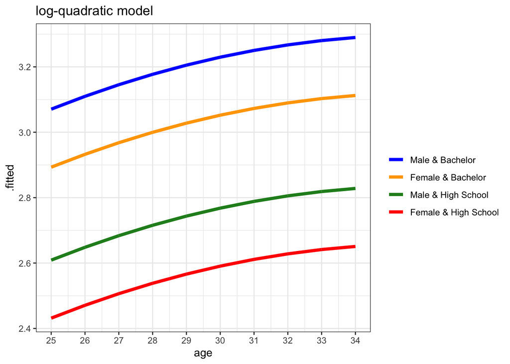

```r
dm8 <- augment(m8, data=df)
ggplot() +
  geom_line(data=dm8, aes(x=age, y=.fitted,
                          group=interaction(-female, bachelor),
                          color=interaction(-female, bachelor)),
            size=1.5) +
  scale_x_continuous(breaks=seq(25,35,1)) +
  scale_color_manual(name="",labels=labs, values=c("red", "forestgreen", "orange", "blue")) +
  guides(color=guide_legend(reverse=TRUE)) +
  ggtitle("log-quadratic model") +
  theme_bw()
```

### Log-Log model:

```r
m9 <- lm(log(ahe) ~ log(age) + bachelor + female, data=df)
summary(m9)
```

```
##
## Call:
## lm(formula = log(ahe) ~ log(age) + bachelor + female, data = df)
##
## Residuals:
##    Min     1Q Median     3Q    Max
## -2.594 -0.287  0.010  0.302  2.062
##
## Coefficients:
##             Estimate Std. Error t value Pr(>|t|)
## (Intercept)   0.3233     0.1961    1.65    0.099 .
## log(age)      0.7154     0.0578   12.37   <2e-16 ***
## bachelor      0.4615     0.0115   40.22   <2e-16 ***
## female       -0.1775     0.0116  -15.27   <2e-16 ***
## ---
## Signif. codes:  0 '***' 0.001 '**' 0.01 '*' 0.05 '.' 0.1 ' ' 1
##
## Residual standard error: 0.477 on 7094 degrees of freedom
## Multiple R-squared:  0.209,  Adjusted R-squared:  0.208
## F-statistic:  623 on 3 and 7094 DF,  p-value: <2e-16
```

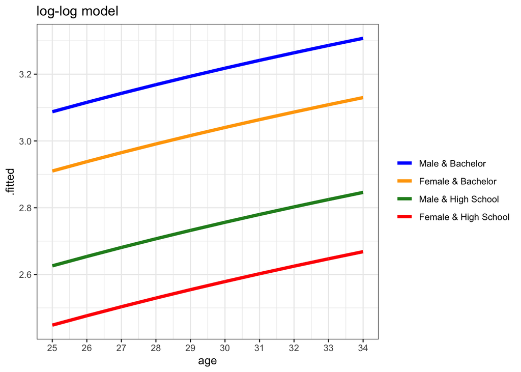

```r
dm9 <- augment(m9, data=df)
ggplot() +
  geom_line(data=dm9, aes(x=age, y=.fitted,
                          group=interaction(-female, bachelor),
                          color=interaction(-female, bachelor)),
            size=1.5) +
  scale_x_continuous(breaks=seq(25,35,1)) +
  scale_color_manual(name="",labels=labs, values=c("red", "forestgreen", "orange", "blue")) +
  guides(color=guide_legend(reverse=TRUE)) +
  ggtitle("log-log model") +
  theme_bw()
```